# ReCell Project: Supervised Learning - Foundations

### TEST FOR LINEARITY AND INDEPENDENCE

**Why the test?**

- Linearity describes a straight-line relationship between two variables, predictor variables must have a linear relation with the dependent variable.
- The independence of the error terms (or residuals) is important. If the residuals are not independent, then the confidence intervals of the coefficient estimates will be narrower and make us incorrectly conclude a parameter to be statistically significant.

**How to check linearity and independence?**

- Make a plot of fitted values vs residuals.
- If they don't follow any pattern, then we say the model is linear and residuals are independent.
- Otherwise, the model is showing signs of non-linearity and residuals are not independent.

**How to fix if this assumption is not followed?**

- We can try to transform the variables and make the relationships linear.

```python
# let us create a dataframe with actual, fitted and residual values
df_pred = pd.DataFrame()

df_pred["Actual Values"] = y_train  # actual values
df_pred["Fitted Values"] = olsmodel3.fittedvalues  # predicted values
df_pred["Residuals"] = olsmodel3.resid  # residuals

df_pred.head()
```

|  | Actual Values | Fitted Values | Residuals |
| --- | --- | --- | --- |
| 3026 | 4.087 | 3.869 | 0.219 |
| 1525 | 4.448 | 4.558 | -0.109 |
| 1128 | 4.315 | 4.270 | 0.045 |
| 3003 | 4.282 | 4.246 | 0.036 |
| 2907 | 4.456 | 4.543 | -0.086 |

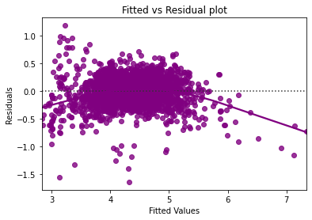

```python
# let's plot the fitted values vs residuals

sns.residplot(
    data=df_pred, x="Fitted Values", y="Residuals", color="purple", lowess=True
)
plt.xlabel("Fitted Values")
plt.ylabel("Residuals")
plt.title("Fitted vs Residual plot")
plt.show()
```

- The scatter plot shows the distribution of residuals (errors) vs fitted values (predicted values).
- If there exist any pattern in this plot, we consider it as signs of non-linearity in the data and a pattern means that the model doesn't capture non-linear effects.
- **We see no pattern in the plot above. Hence, the assumptions of linearity and independence are satisfied.**

### TEST FOR NORMALITY

**Why the test?**

- Error terms, or residuals, should be normally distributed. If the error terms are not normally distributed, confidence intervals of the coefficient estimates may become too wide or narrow. Once confidence interval becomes unstable, it leads to difficulty in estimating coefficients based on minimization of least squares. Non-normality suggests that there are a few unusual data points that must be studied closely to make a better model.

**How to check normality?**

- The shape of the histogram of residuals can give an initial idea about the normality.
- It can also be checked via a Q-Q plot of residuals. If the residuals follow a normal distribution, they will make a straight line plot, otherwise not.
- Other tests to check for normality includes the Shapiro-Wilk test.
  - Null hypothesis: Residuals are normally distributed
  - Alternate hypothesis: Residuals are not normally distributed

**How to fix if this assumption is not followed?**

- We can apply transformations like log, exponential, arcsinh, etc. as per our data.

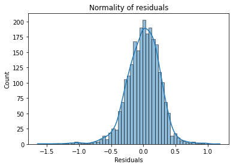

```python
sns.histplot(data=df_pred, x="Residuals", kde=True)
plt.title("Normality of residuals")
plt.show()
```

- The histogram of residuals does have a bell shape.
- Let's check the Q-Q plot.

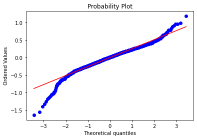

```python
stats.probplot(df_pred["Residuals"], dist="norm", plot=pylab)
plt.show()
```

- The residuals more or less follow a straight line except for the tails.
- Let's check the results of the Shapiro-Wilk test.

```python
stats.shapiro(df_pred["Residuals"])
```

```
ShapiroResult(statistic=0.967004656791687, pvalue=4.084117499781e-23)
```

- Since p-value < 0.05, the residuals are not normal as per the Shapiro-Wilk test.
- Strictly speaking, the residuals are not normal.
- However, as an approximation, we can accept this distribution as close to being normal.
- **So, the assumption is satisfied.**

### TEST FOR HOMOSCEDASTICITY

- **Homoscedascity**: If the variance of the residuals is symmetrically distributed across the regression line, then the data is said to be homoscedastic.
- **Heteroscedascity**: If the variance is unequal for the residuals across the regression line, then the data is said to be heteroscedastic.

**Why the test?**

- The presence of non-constant variance in the error terms results in heteroscedasticity. Generally, non-constant variance arises in presence of outliers.

**How to check for homoscedasticity?**

- The residual vs fitted values plot can be looked at to check for homoscedasticity. In the case of heteroscedasticity, the residuals can form an arrow shape or any other non-symmetrical shape.
- The goldfeldquandt test can also be used. If we get a p-value > 0.05 we can say that the residuals are homoscedastic. Otherwise, they are heteroscedastic.
  - Null hypothesis: Residuals are homoscedastic
  - Alternate hypothesis: Residuals have heteroscedasticity

**How to fix if this assumption is not followed?**

- Heteroscedasticity can be fixed by adding other important features or making transformations.

```python
import statsmodels.stats.api as sms
from statsmodels.compat import lzip

name = ["F statistic", "p-value"]
test = sms.het_goldfeldquandt(df_pred["Residuals"], x_train6)
lzip(name, test)
```

```
[('F statistic', 1.0559085197297338), ('p-value', 0.17364530651957955)]
```

**Since p-value > 0.05, we can say that the residuals are homoscedastic. So, this assumption is satisfied.**

### **Now that we have checked all the assumptions of linear regression and they are satisfied, let's go ahead with prediction.**

```python
# predictions on the test set
pred = olsmodel3.predict(x_test6)

df_pred_test = pd.DataFrame({"Actual": y_test, "Predicted": pred})
df_pred_test.sample(10, random_state=1)
```

|  | Actual | Predicted |
| --- | --- | --- |
| 1995 | 4.567 | 4.463 |
| 2341 | 3.696 | 3.935 |
| 1913 | 3.592 | 3.729 |
| 688 | 4.306 | 4.137 |
| 650 | 4.522 | 5.136 |
| 2291 | 4.259 | 4.406 |
| 40 | 4.998 | 5.428 |
| 1884 | 3.875 | 3.919 |
| 2538 | 4.207 | 3.854 |
| 45 | 5.380 | 5.210 |

- We can observe here that our model has returned good prediction results for most, and the actual and predicted values are comparable.
- We can also visualize comparison result as a bar graph.

**Note**: As the number of records is large, for representation purpose, we are taking a sample of 25 records only.

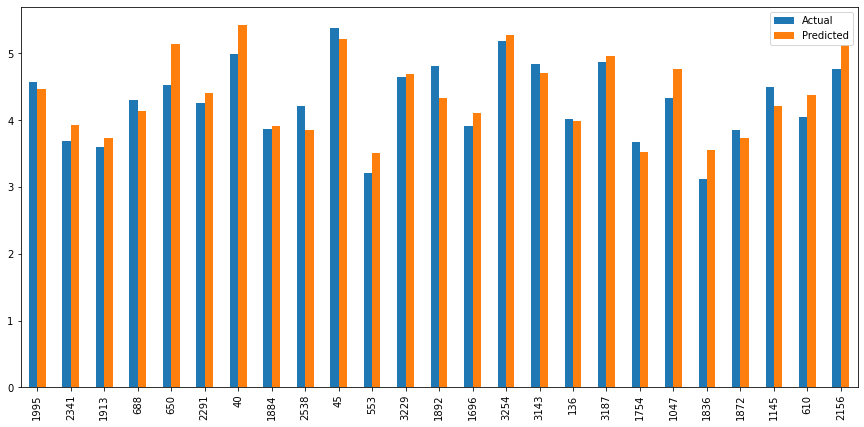

```python
df3 = df_pred_test.sample(25, random_state=1)
df3.plot(kind="bar", figsize=(15, 7))
plt.show()
```

## Final Model Summary

```python
x_train_final = x_train6.copy()
x_test_final = x_test6.copy()

olsmodel_final = sm.OLS(y_train, x_train_final).fit()
print(olsmodel_final.summary())
```

```
                            OLS Regression Results
==============================================================================
Dep. Variable:         used_price_log   R-squared:                       0.799
Model:                            OLS   Adj. R-squared:                  0.798
Method:                 Least Squares   F-statistic:                     734.5
Date:                Sun, 30 Jan 2022   Prob (F-statistic):               0.00
Time:                        00:46:08   Log-Likelihood:                -189.65
No. Observations:                2417   AIC:                             407.3
Df Residuals:                    2403   BIC:                             488.4
Df Model:                          13
Covariance Type:            nonrobust
=======================================================================================
                          coef    std err          t      P>|t|      [0.025      0.975]
---------------------------------------------------------------------------------------
const                   2.7217      0.041     66.921      0.000       2.642       2.801
screen_size             0.0560      0.002     34.595      0.000       0.053       0.059
main_camera_mp          0.0292      0.001     19.757      0.000       0.026       0.032
selfie_camera_mp        0.0179      0.001     16.397      0.000       0.016       0.020
ram                     0.0362      0.006      6.419      0.000       0.025       0.047
days_used            9.417e-05   2.75e-05      3.422      0.001    4.02e-05       0.000
new_price               0.0009   3.36e-05     27.206      0.000       0.001       0.001
brand_name_Celkon      -0.1580      0.058     -2.717      0.007      -0.272      -0.044
brand_name_Micromax    -0.1543      0.030     -5.081      0.000      -0.214      -0.095
brand_name_Nokia        0.0915      0.035      2.643      0.008       0.024       0.159
brand_name_Spice       -0.1270      0.056     -2.273      0.023      -0.237      -0.017
os_Others              -0.1488      0.033     -4.560      0.000      -0.213      -0.085
4g_yes                  0.0996      0.015      6.561      0.000       0.070       0.129
5g_yes                 -0.0735      0.035     -2.123      0.034      -0.141      -0.006
==============================================================================
Omnibus:                      316.251   Durbin-Watson:                   1.952
Prob(Omnibus):                  0.000   Jarque-Bera (JB):             1137.486
Skew:                          -0.624   Prob(JB):                    9.96e-248
Kurtosis:                       6.121   Cond. No.                     8.36e+03
==============================================================================

Notes:
[1] Standard Errors assume that the covariance matrix of the errors is correctly specified.
[2] The condition number is large, 8.36e+03. This might indicate that there are
strong multicollinearity or other numerical problems.
```

```python
# checking model performance on train set (seen 70% data)
print("Training Performance\n")
olsmodel_final_train_perf = model_performance_regression(
    olsmodel_final, x_train_final, y_train
)
olsmodel_final_train_perf
```

```
Training Performance
```

|  | RMSE | MAE | MAPE |
| --- | --- | --- | --- |
| 0 | 40.895 | 18.928 | 20.897 |

```python
# checking model performance on test set (seen 30% data)
print("Test Performance\n")
olsmodel_final_test_perf = model_performance_regression(
    olsmodel_final, x_test_final, y_test
)
olsmodel_final_test_perf
```

```
Test Performance
```

|  | RMSE | MAE | MAPE |
| --- | --- | --- | --- |
| 0 | 26.916 | 17.573 | 20.959 |

## Actionable Insights

- The model explains ~80% of the variation in the data and can predict within 17.6 euros of the used device price.
- The most significant predictors of the used device price are the price of a new device of the same model, the size of the devices screen, the resolution of the rear and front cameras, the number of days it was used, the amount of RAM, and the availability of 4G and 5G network.
- A unit increase in new model price will result in a 0.09% increase in the used device price. *[ 100* {exp(0.0009) - 1} = 0.09 ]*
- A unit increase in size of the device's screen will result in a 5.76% increase in the used device price. *[ 100* {exp(0.0560) - 1} = 5.76 ]*
- A unit increase in the amount of RAM will result in a 3.69% increase in the used device price. *[ 100* {exp(0.0362) - 1} = 3.69 ]*